# WCANN_similarity_heatmap_distance

[figure not shown]

```r
ggsave(plot = wcann_jaccard_heatmap, width = 2.8, height = 3, unit = "in", path = here::here("figures","wcann"),file = "wcann_jaccard_heatmap.eps")
```

```r
#bray curtis similarity
(wcann_bray_heatmap <- ggplot(wcann_distances_dissimilarities_allyears_jaccard_rounded_allcombos,aes(as.factor(year),distance_km_10s, color = bray_similarity_mean_10s)) +
  geom_point(shape = "-", size = 5) +
  scale_color_gradientn(colors =
c("purple" ,"cornflowerblue", "green" , "yellow" ,"orange", "red")
  ) +
  scale_x_discrete(limits=levels(wcann_distances_dissimilarities_allyears_jaccard_rounded_allcombos$year.f), breaks = c("2003", "2005","2010", "2015")) +
  labs(y = "Distance (km)", x = "Year", color = "Bray Curtis Similarity") +
  theme_classic() +
    theme(axis.text.x = element_text(angle = 90)))

ggsave(plot = wcann_bray_heatmap, width = 3.3, height = 3, unit = "in", path = here::here("figures","wcann"),file = "wcann_bray_heatmap.jpg")
```

```r
ggsave(plot = wcann_bray_heatmap, width = 3.3, height = 3, unit = "in", path = here::here("figures","wcann"),file = "wcann_bray_heatmap.eps")
ggsave(plot = wcann_jaccard_heatmap, width = 2.8, height = 3, unit = "in", path = here::here("figures","wcann"),file = "wcann_jaccard_heatmap.jpg")
```

[figure not shown]

```r
ggsave(plot = wcann_jaccard_heatmap, width = 2.8, height = 3, unit = "in", path = here::here("figures","wcann"),file = "wcann_jaccard_heatmap.eps")
```

Box plots

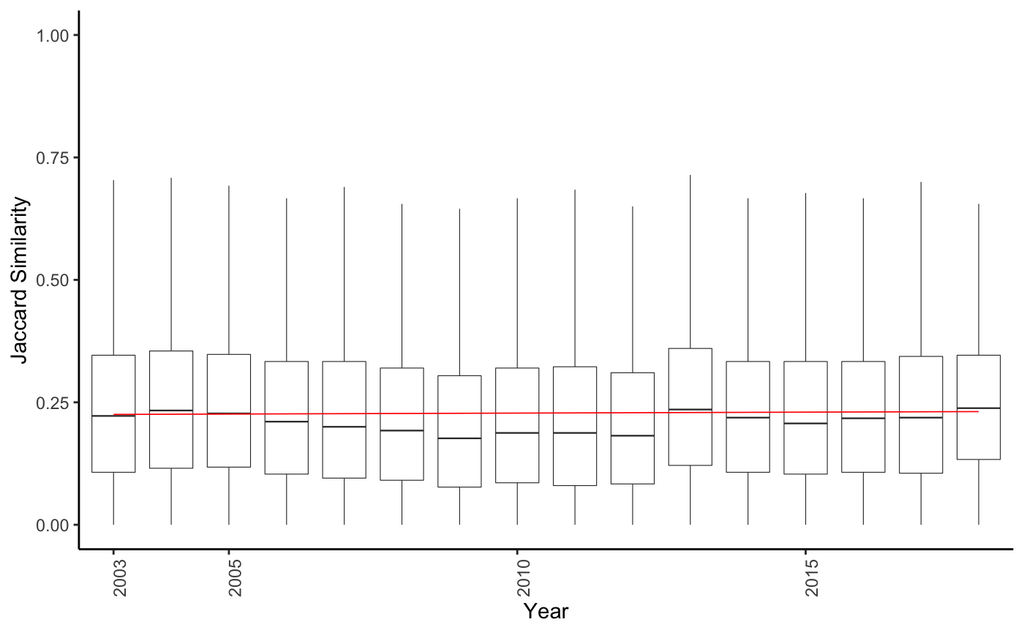

```r
library(ggpubr)

#jaccard similarity
(wcann_jaccard_boxplot <- ggplot(wcann_distances_dissimilarities_allyears,aes(year.f,jaccard_similarity)) +
  geom_boxplot(outlier.shape = NA, lwd = 0.2) +
  labs(x="Year", y = "Jaccard Similarity") +
  scale_x_discrete(limits=levels(wcann_distances_dissimilarities_allyears$year.f), breaks = c("2003", "2005","2010", "2015")) +
  geom_smooth(method = "lm", se=FALSE, color="red", aes(group=1), lwd = 0.3) +
  stat_regline_equation(label.x = 3, label.y = 32) +
 # ylim(c(0,0.68)) +
  theme_classic() +
  theme(axis.text.x = element_text(angle = 90)))
```

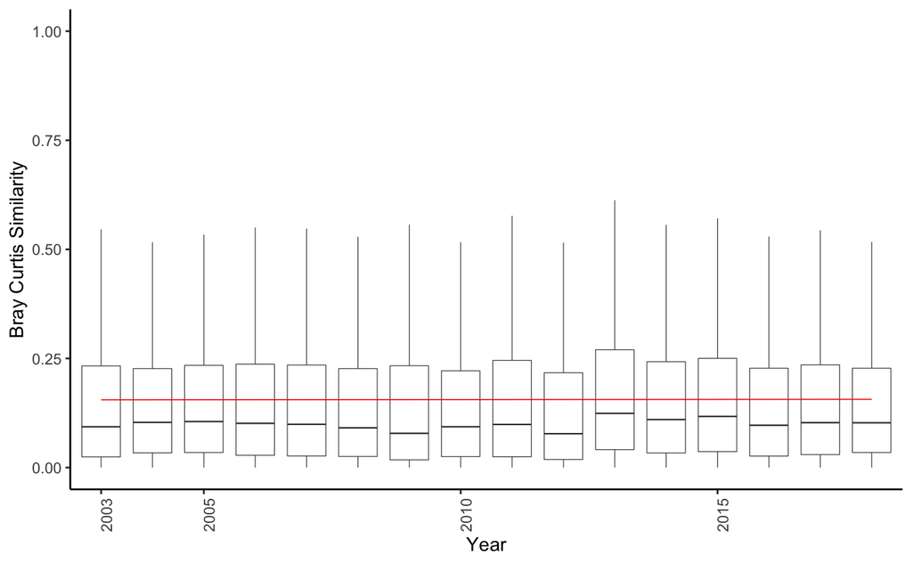

```r
#bray curtis similarity
(wcann_bray_boxplot <- ggplot(wcann_distances_dissimilarities_allyears,aes(year.f,bray_curtis_similarity)) +
  geom_boxplot(outlier.shape = NA, lwd = 0.2) +
  labs(x="Year", y = "Bray Curtis Similarity") +
  scale_x_discrete(limits=levels(wcann_distances_dissimilarities_allyears$year.f), breaks = c("2003", "2005","2010", "2015")) +
  geom_smooth(method = "lm", se=FALSE, color="red", aes(group=1), lwd = 0.3) +
  stat_regline_equation(label.x = 3, label.y = 32) +
#    ylim(c(0,0.48)) +
  theme_classic() +
  theme(axis.text.x = element_text(angle = 90)))
```

```r
#corresponding models
wcann_avg_jaccard_mod <- lm(data = wcann_distances_dissimilarities_allyears, formula = jaccard_similarity ~ as.numeric(year))

wcann_avg_bray_curtis_mod <- lm(data = wcann_distances_dissimilarities_allyears, formula = bray_curtis_similarity ~ as.numeric(year))

summary(wcann_avg_jaccard_mod)
```

```
Call:
lm(formula = jaccard_similarity ~ as.numeric(year), data = wcann_distances_dissimilarities_allyears)

Residuals:
     Min       1Q   Median       3Q      Max
-0.23109 -0.13122 -0.02303  0.10457  0.77471

Coefficients:
                   Estimate Std. Error t value Pr(>|t|)
(Intercept)      -5.493e-01  7.645e-02  -7.184 6.75e-13 ***
as.numeric(year)  3.867e-04  3.803e-05  10.169  < 2e-16 ***
---
Signif. codes:  0 ‘***’ 0.001 ‘**’ 0.01 ‘*’ 0.05 ‘.’ 0.1 ‘ ’ 1

Residual standard error: 0.1655 on 1095634 degrees of freedom
Multiple R-squared:  9.437e-05, Adjusted R-squared:  9.345e-05
F-statistic: 103.4 on 1 and 1095634 DF,  p-value: < 2.2e-16
```

```r
summary(wcann_avg_bray_curtis_mod)
```

```
Call:
lm(formula = bray_curtis_similarity ~ as.numeric(year), data = wcann_distances_dissimilarities_allyears)

Residuals:
     Min       1Q   Median       3Q      Max
-0.15639 -0.12927 -0.05859  0.07830  0.84486

Coefficients:
                   Estimate Std. Error t value Pr(>|t|)
(Intercept)      -1.102e-02  7.823e-02  -0.141    0.888
as.numeric(year)  8.296e-05  3.891e-05   2.132    0.033 *
---
Signif. codes:  0 ‘***’ 0.001 ‘**’ 0.01 ‘*’ 0.05 ‘.’ 0.1 ‘ ’ 1

Residual standard error: 0.1694 on 1095634 degrees of freedom
Multiple R-squared:  4.149e-06, Adjusted R-squared:  3.236e-06
F-statistic: 4.545 on 1 and 1095634 DF,  p-value: 0.03301
```

Now, merge the previous two plots

```r
#pull out legend
wcann_legend_heatmaps <- get_legend(wcann_jaccard_heatmap + labs(color = "Similarity"))

wcann_merge <- plot_grid(wcann_jaccard_heatmap + theme(legend.position = "none", axis.title.x = element_blank(), axis.text.x = element_blank()) , wcann_bray_heatmap + theme(legend.position = "none", axis.title.x = element_blank(), axis.text.x = element_blank(), axis.title.y = element_blank()), wcann_legend_heatmaps, wcann_jaccard_boxplot, wcann_bray_boxplot,  nrow = 2, ncol = 3, align = "hv", axis = "lb")
```

###maybe i’ll do this latitudeer? maybe not At its heart, this graphic is just a ggplot() with a geom_raster() layer. The complication is, geom_raster() requires equally spaced points in both the x- and y-direction. The rest of this post is about how to make that happen.

Linear Interpolatitudeion

I interpolatitudee in the distance direction first, because I think this is the better assumption: as you go down further away, a reasonable way to estimate the similarity at a distance which you did not measure is to draw a straight line between the similarity at the distance that you did measure. (Not great, but sure)

```r
estimate_jac_sim_by_year <- function(target_year, target_distance) {
  data_for_year <- wcann_distances_dissimilarities_allyears[year == target_year]

  # approx() is one way to do a linear interpolatitudeion
  approx(data_for_year$distance, data_for_year$jaccard_similarity, xout = target_distance)$y
}

estimate_jac_sim_by_year(1990, c(0,3000,300000))
```

Expand data inputs

```r
temp_interp_depth <- data.table(expand.grid(
  # the same years as wcann spring
  year = wcann_years,
  # ddistances can now be any value
  distance = seq(0, max(wcann_distances_dissimilarities_allyears$distance), by = 10))
)

temp_interp_depth[,jaccard_similarity_modeled := estimate_jac_sim_by_year(year,distance), year]
```

Visualize

```r
ggplot(temp_interp_depth,aes(year,distance, color = jaccard_similarity_modeled)) +
  geom_point() +
   scale_colour_gradient2(
    midpoint = 0.5,
    high = scales::muted("red"),
    low = scales::muted("blue")
  )
```

```r
estimate_jac_sim_by_distance <- function(target_distance, target_year) {
  data_for_distance <- temp_interp_depth[distance == target_distance,]
    setkey(data_for_distance, year)
  approx(data_for_distance$year, data_for_distance$jaccard_similarity_modeled, xout = target_year)$y
}

estimate_jac_sim_by_distance(
  target_distance = 1000000,
  target_year = c(1990,1998,2000)
)
```

Expand year grid

```r
jac_sim_raster <- data.table(expand.grid(
  # dates can now be any value
  year = seq(min(wcann_years), max(wcann_years), by = 1),
  # depths must be the same as in temp_interp_depth
  distance = unique(temp_interp_depth$distance))
)

jac_sim_raster[,jaccard_similarity_modeled := estimate_jac_sim_by_distance(distance,year),by = distance]
```

```r
ggplot(jac_sim_raster, aes(year, distance, fill = jaccard_similarity_modeled)) +
  geom_raster() +
  scale_fill_gradientn(colors =
c("purple" ,"blue"  , "green" , "yellow" ,"orange", "red")
  ) +
  coord_cartesian(expand = FALSE)
```